# Exploración exportaciones de Oro en Latam

Actualizado

19 de julio de 2023

Proyecto que busca entender cómo funciona la minería ilegal en Latinoamerica, a través de datos de exportaciones de oro. Los países a analizar serán:

- Perú
- Colombia
- Brasil
- Bolivia
- Ecuador

Según el último [Arancel de Aduanas 2022, aprobado por DS 404-2021-EF](https://www.sunat.gob.pe/legislacion/diccionario/arancel/Diccionario_Arancel_de_Aduanas_2022.pdf), las partidas donde mencionan oro son los siguientes.

En el **Capítulo 26**, que se refiere a “Minerales metalíferos, escorias y cenizas”

- 26.16 : Minerales de los metales preciosos y sus concentrados.
  - 2616.90.10.00 : Minerales de oro y sus concentrados

También figura en el **Capítulo 28** que habla de “Productos químicos inorgánicos; compuestos inorgánicos u orgánicos de metal precioso, de elementos radiactivos, de metales de las tierras raras o de isótopos”

- 28.43 : Metal precioso en estado coloidal; compuestos inorgánicos u orgánicos de metal precioso, aunque no sean de constitución química definida; amalgamas de metal precioso.
  - 2843.30.00.00 : Compuestos de oro

En el **Capítulo 71**, que se refiere a “Perlas naturales o cultivadas, piedras preciosas o semipreciosas, metales preciosos, chapados de metal precioso (plaqué) y manufacturas de estas materias; bisutería; monedas”

- 71.08 : Oro (incluido el oro platinado) en las demás formas en bruto o semilabrado, o en polvo.
  - 7108.11.00.00 : Polvo
  - 7108.12.00.00 : Oro en las demás formas semilabrado
  - 7108.13.00.00 : Oro en polvo y en las demás formas en bruto
  - 7108.20.00.00 : Para uso monetario

Hay que tener cuidado al analizar las exportaciones e importaciones de varios países o una región determinada. Por ejemplo, el Centro de Investigación de la Economía Mundial - CEPII de Francia, tiene una base de datos de comercio internacional llamada BACI. En esta base de datos, se muestra flujos bilaterales de comercio entre países, pero puede haber duplicados o errores.

Por ejemplo, en su metodología señalan que lo siguiente:

- Valores de importacón son registrados como CIF, mientras que los valores de exportación son registrados como FOB. Esto puede generar discrepancias en los datos.
- Hay errores en la declaración de aduanas, ademas que no se sabe el destino final de las mercancías, discrepancias en la clasificación de productos, entre otros.

Para tener datos mas certeros sobre el oro en la región, se puede hacer una comparación de exportaciones de un país o territorio, y compararlo con cifras de producción.

La [Organización de los Estados Americanos](https://www.oas.org/es/sms/ddot/docs/Tras-el-dinero-del-oro-ilicito-El-caso-de-Peru.pdf) hizo un ejercicio similar con datos de Perú como se puede ver en la siguiente imagen:

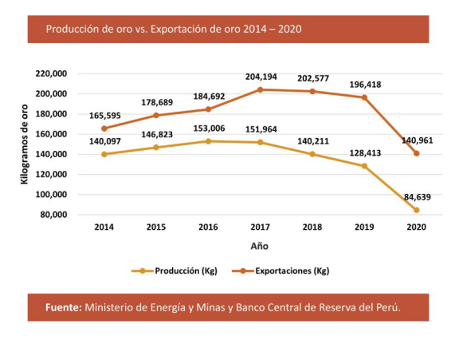

Comparación de exportaciones de oro vs producción - Perú

# Objetivos para reporte

- Descargar datos de **exportaciones** de oro de los países mencionados
- Descargar datos de **producción** de oro de los países mencionados
- Comparar exportaciones vs producción
- Conocer principales destinos y compañias que compran oro

# Análisis de datos

## Perú

### Principales exportadores e importadores de oro en Perú

**Exportadores**

**Total**

| exportador | peso_neto_tm | porcentaje_tm | evolution_tm |
| --- | --- | --- | --- |
| COMPANIA MINERA ARES S.A.C. | 1305 | 54.149377593360995 | [9, 42, 175, 174, 188, 117, 121, 197, 195, 87, 0] |
| MINERA BOROO MISQUICHILCA S.A. | 404 | 16.763485477178424 | [56, 58, 61, 68, 62, 38, 19, 10, 23, 9, 0] |
| CIA MINERA COIMOLACHE SA | 268 | 11.120331950207468 | [34, 35, 34, 31, 36, 32, 26, 27, 12, 1, 0] |
| MINERA YANACOCHA S.R.L. | 220 | 9.12863070539419 | [49, 41, 34, 27, 30, 27, 10, 1, 1, 0, 0] |
| MINERA LAYTARUMA S.A. | 70 | 2.904564315352697 | [0, 0, 2, 19, 8, 3, 24, 14, 0, 0, 0] |
| COMPAñIA DE MINAS BUENAVENTURA S.A.A. | 54 | 2.240663900414938 | [1, 7, 1, 3, 30, 5, 7, 0, 0, 0, 0] |
| SHAHUINDO S.A.C. | 49 | 2.033195020746888 | [0, 0, 0, 0, 0, 0, 12, 14, 16, 7, 0] |
| CIA MINERA PODEROSA S A | 15 | 0.6224066390041494 | [0, 0, 0, 0, 1, 1, 11, 2, 0, 0, 0] |
| MINSUR S. A. | 12 | 0.4979253112033195 | [0, 0, 0, 0, 0, 0, 3, 7, 1, 1, 0] |
| LA ARENA S.A. | 4 | 0.16597510373443983 | [0, 0, 4, 0, 0, 0, 0, 0, 0, 0, 0] |

[output cut: 1361 more lines]

## Brasil

En Brasil también se hizo una investigación comparando el oro producido y exportado. Se puede ver en el siguiente [enlace](https://www.sustainablesupplychains.org/brazil-exports-illegal-gold-how-to-tackle-the-problem/). Luego de revisar los datos de este país, encontramos que no brindan detalle sobre las compañias que exportan el oro, ni las que compran. Solo indican el país de destino. De hecho, en 2021 Mongabay publicó un artículo sobre la [falta de transparencia en las exportaciones de oro](https://news.mongabay.com/2021/11/top-brazil-gold-exporter-leaves-a-trail-of-criminal-probes-and-illegal-mines/). Tal vez se puede hacer una búsqueda en las importaciones de los principales países que compran oro a Brasil, para ver si se puede encontrar alguna coincidencia o revelar el nombre de las compañías brasileñas que exportaron oro.

# Referencias

- [Arancel de Aduanas 2022, aprobado por DS 404-2021-EF](https://www.sunat.gob.pe/legislacion/diccionario/arancel/Diccionario_Arancel_de_Aduanas_2022.pdf)
- [Más de 1500 toneladas de oro se exportaron desde el Perú sin que se sepa quién la extrajo](https://convoca.pe/investigacion/mas-de-1500-toneladas-de-oro-se-exportaron-desde-el-peru-sin-que-se-sepa-quien-las)
- [Las rutas del oro ilegal: mapas satelitales muestran expansión minera en la Amazonía](https://ojo-publico.com/ambiente/territorio-amazonas/mineria-ilegal-oro-avanza-la-amazonia-brasil-colombia-y-peru)
- [Oro en Perú, datos de exportaciones e importaciones 2021](https://oec.world/es/profile/bilateral-product/gold/reporter/per)
- [EEUU compró exportaciones de Oro a Perú](https://www.iimp.org.pe/raiz/ee.-uu.-compro-el-22-de-las-exportaciones-de-oro-peruano-entre-enero-y-octubre-de-2020) - Se puede rastrear cotización de oro
- [Tras el dinero del oro ilícito, informe OAS del caso Perú](https://www.oas.org/es/sms/ddot/docs/Tras-el-dinero-del-oro-ilicito-El-caso-de-Peru.pdf)
- [Produccioń anual de oro, ranking desde 2010](https://www.gold.org/goldhub/data/gold-production-by-country)
- [Sistema HS de las Naciones UNIDAS](https://unstats.un.org/wiki/pages/viewpage.action?pageId=87426301)
- [Tablas de correspondencia para diferentes sistemas de comercio](https://unstats.un.org/unsd/classifications/Econ).